# Final

## Research Question

How does party fragmentation within a political system affect voter turnout in electoral democracies?

## Introduction

There are a number of studies in electoral research that have attempted to investigate the relationship between party fragmentation and measures of democratic strength. The direction of the effect, however, is widely disputed among political scientists. On the one hand, some scholars argue that greater fragmentation fosters pluralism, representation, and policy innovation by ensuring that a wider range of political interests are represented in the decision-making process. This, in turn, can enhance democratic legitimacy and participation. Other researchers contend that high levels of fragmentation can lead to governmental instability, inefficiency, and legislative gridlock, ultimately weakening democratic performance.

Multiple measures of democracy have been studied in the literature, including governmental stability, accountability, corruption, turnout, public goods provision, female representation and the representation of minorities (Valentim and Dinas 2024). The empirical findings from these studies are often contradictory concerning the direction of the effect of party fragmentation on democratic quality, even when comparing the same indicators.

A number of studies have also focused on characterizing the specific relationship between party fragmentation and political participation, measured by voter turnout. A large group of scholars argues that party system fragmentation likely depresses turnout since citizens vote for a small part of the government which will likely form a coalition to rule. Additionally, each individual candidate has a lower likelihood of winning elections in a fragmented party system, which may also discourage voter turnout. Additionally, a higher number of parties increase the cost of voting by increasing information costs as one needs to research a higher number of candidates and policies to make a decision on who to vote for. It also creates a more complex system, which may put uneducated voters at a disadvantage. In empirical research, party fragmentation has also been found to be negatively correlated with voter turnout (Franklin and Miño 1998; Geys and Heyndels 2006; Henderson and McEwen 2010; Jackman and Milner 1995; Kostadinova and Power 2007; Lehoucq and Wall 2004; Radcliff and Davis 2000).

However, there is also empirical evidence pointing to a positive relationship between party fragmentation and voter turnout (Banducci and Karp 2009), though the authors find a stronger relationship when regressing on party polarization. The theoretical foundation behind this research is that a greater number of parties may increase voter turnout by providing more ideological options that align with citizens’ preferences, thereby encouraging participation. Higher competition in the party system could also be associated with better policies that are more representative of the population, thus changing the voter’s cost-benefit calculation when deciding to vote. However, some scholars argue that an excessive number of parties can dilute ideological clarity and create confusion, potentially discouraging voter engagement.

All of the studies above that use country-level aggregate data focus on industrialized democracies. The justification for this is that those kinds of regimes are more consolidated democracies with very limited experience with authoritarianism and where the right to vote is generally guaranteed. Other studies have limited their research to a number of elections in a particular country, hoping to control for the endogeneity of political parties. Few studies have expanded the number of countries considered to all electoral democracies. Blais and Dobrzynska (1998) assess the effect of many variables on turnout in 324 democratic national lower house elections held in 91 countries, between 1972 and 1995. They show that the number of parties has a statistically significant and negative effect on turnout. Though they conclude that the results did not differ dramatically from studies that consider a narrower sample of countries, the authors do not theorize about how party fragmentation might operate differently when influencing turnout in less established democracies. In fact, to my knowledge, no studies theorize about that distinction and use large-scale empirical analysis to test it. To fill this gap, I will propose that developing democracies have less institutionalized parties, which presents nuances to the way in which fragmentation can influence turnout.

Studies that focus on developing democracies are more case-study based and do not consider a large sample of countries. For instance, Carew Boulding and David S. Brown attempted to answer the question: “Does the number of political parties influence voter turnout in developing democracies?” Their research focuses on Brazil and Bolivia, concluding that differences in electoral systems shape the relationship between party competition and voter turnout. They find that in Bolivia, an increase in the number of parties is strongly associated with higher turnout, while in Brazil, the relationship is weaker and slightly negative. However, their study is limited to only two countries, which constrains the generalizability of their findings.

## Hypothesis and Theory

The Voter Turnout Model, proposed by Downs (1957), has profoundly influenced theories of electoral behavior. Downs argues that voters are rational actors who weigh the costs and benefits of voting. In his model, the individual benefit of voting is effectively zero, as no single vote is likely to determine the outcome of an election. This would suggest that no one should vote, since the costs—including registration, travel to polling places, and gathering information—outweigh the expected utility. However, empirical evidence shows that substantial numbers of people do vote across democracies, indicating that additional, non-material or expressive benefits must play a role.

To better understand these dynamics, Powell (1982) identifies three categories of factors that shape political participation: the socioeconomic environment, the constitutional setting, and the party system. My analysis builds on this framework by controlling for the first two in order to isolate the effect of party fragmentation, a key characteristic of party systems.

I hypothesize that the degree of party institutionalization moderates the effect of party fragmentation on voter turnout. In developing democracies with less consolidated institutions, increasing fragmentation—especially over time—can trigger skepticism among voters, as newer or smaller parties tend to be less institutionalized. The effect on turnout, however, is theoretically ambiguous and depends on voter perceptions. If voters interpret fragmentation as a sign of elite disunity or opportunism, this may erode trust in the system and reduce turnout. Alternatively, if fragmentation increases the perceived stakes of elections or enhances representation, it may stimulate greater participation. Party institutionalization refers to the extent to which parties are socially rooted, programmatically coherent, and organizationally autonomous Randall and Svåsand (2002). In weakly institutionalized systems, high fragmentation exacerbates information costs, making it harder for voters to distinguish between poorly defined political options. As Downs (1957) suggests, when these costs outweigh perceived benefits, turnout declines. Low institutionalization may also undermine party credibility and voters’ ability to make informed choices, disproportionately affecting less educated or lower-information voters.

Additionally, a proliferation of weak parties can dilute party brands and deepen citizen disillusionment, suppressing political engagement. Conversely, institutionalized parties tend to maintain clearer ideological profiles, mobilize voters through established networks, and reduce uncertainty. In such contexts, fragmentation may actually encourage participation by offering more meaningful and credible choices. That said, fragmentation can also mobilize turnout under certain conditions—for example, in highly polarized environments where voters perceive rising competition or potential threats. In these cases, even poorly institutionalized parties may benefit from heightened salience, driving voters to the polls despite high information costs.

Ultimately, my argument emphasizes that fragmentation’s effect on turnout is conditional on institutionalization. In systems with strong parties, fragmentation may reflect healthy political pluralism and enhance democratic participation. In systems with weak parties, it may instead signal volatility, confusion, or elite self-interest, leading to voter disengagement. This theoretical framework informs my empirical strategy, which includes an interaction term between fragmentation and institutionalization to test whether their combined effect influences turnout in a statistically and substantively meaningful way.

## Data and Research Design

From the Varieties of Democracy (V-Dem) General Dataset v15, I am using the variable on party institutionalization (v2xps_party). The V-Dem Party Institutionalization Index is measured from 0 to 1 and refers to various attributes of the political parties in a country, such as the level and depth of organization, links to civil society, cadres of party activists, party supporters within the electorate, coherence of party platforms and ideologies, party-line voting among representatives within the legislature. A high score on these attributes generally indicates a more institutionalized party system (V-Dem). The index is calculated by aggregating scaled indicators of other variables related to party strength, party organizations (v2psorgs), party branches (v2psprbrch), party linkages (v2psprlnks), distinct party platforms (v2psplats), and legislative party cohesion (v2pscohesv).

From the World Bank’s World Development indicators I am using variables to control for the effect of the socio-economic environment on voter turnout. In particular, I chose GDP per capita, life expectancy, total population and population density for that purpose. Literacy rates would have also been important to consider as a significant measure of human capital, but there were 85% of missing values, so the variable was removed from the analysis. Lastly, from Freedom House, I used the political rights score for each country-year observation to only run the analysis for countries with a political rights score under 3, used to classify electoral democracies.

Table 1: Descriptive Statistics of Key Variables

| Variable | Mean | SD | Min | Max |
| --- | --- | --- | --- | --- |
| Turnout | 71.63 | 14.71 | 2.73 | 97.16 |
| Fragmentation | 4.47 | 2.19 | 1.23 | 17.95 |
| Strength | 0.80 | 0.19 | 0.17 | 1.00 |
| GDP | 17,077.45 | 19,112.24 | 169.20 | 120,000.14 |
| CompulsoryVoting | 0.23 | 0.42 | 0.00 | 1.00 |

I will use a regression model with country-fixed effects and an interaction term to capture the relationship between party fragmentation and voter turnout in the context of my hypothesis. The purpose of including country-fixed effects is to account for variations in the electoral system within countries that may have influenced voter turnout over time, such as electoral reforms that significantly increased or decreased the number of parties. By holding constant cross-country variation in time-invariant unobservable factors, this methodology helps eliminate the influence of potential confounders in voter turnout, such as cultural and institutional differences between countries. Controlling for country-fixed effects thus serves as a valid proxy for the third category of voter turnout determinants identified by Powell (1982): the constitutional environment. Since this environment tends to vary across countries but remains relatively stable over time within countries, fixed effects can effectively account for its impact.

### Country Fixed-Effects (FE) Model

where $\alpha_i$ corresponds to the country fixed effect: unobserved, time-invariant characteristics of country i.

## Results

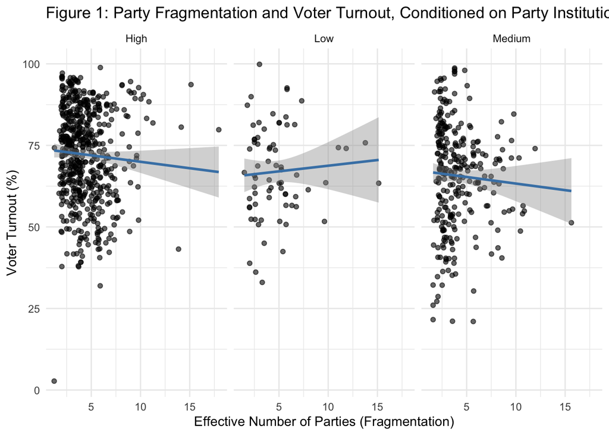

Several control variables perform as expected. Compulsory voting is strongly and positively associated with turnout, consistent with prior findings in the literature. GDP per capita also has a significant positive effect, suggesting that economic development supports electoral participation. The year variable is negative and significant, indicating a general downward time trend in turnout, perhaps reflecting growing global disillusion with political institutions. Population size is also significant and positive, though its substantive impact is small. Other controls, such as life expectancy, do not show statistically significant effects in this model.

Table 2: Fixed Effects Regression on Voter Turnout

|  | (1) |
| --- | --- |
| (Intercept) | 805.080*** |
|  | (126.937) |
| year | −0.376*** |
|  | (0.071) |
| party_fragmentation | 0.713 |
|  | (0.639) |
| party_strength | −2.474 |
|  | (9.030) |
| population | 0.000* |
|  | (0.000) |
| life_expectancy | 0.210 |
|  | (0.266) |
| gdp_percapita | 0.000* |
|  | (0.000) |
| compulsory_voting | 13.319*** |
|  | (3.125) |
| party_fragmentation × party_strength | −1.471 |
|  | (0.913) |
| Num.Obs. | 562 |
| R2 | 0.820 |
| R2 Adj. | 0.788 |
| AIC | 3828.0 |
| BIC | 4200.5 |
| Log.Lik. | −1828.018 |
| RMSE | 6.26 |

+ p < 0.1, * p < 0.05, ** p < 0.01, *** p < 0.001

Table 3: Fixed Effects Regression on Voter Turnout including Partially Free Countries

[output not shown]

+ p < 0.1, * p < 0.05, ** p < 0.01, *** p < 0.001

## Discussion and Policy Implications

Despite the insights provided by the fixed-effects regression model, some limitations constrain the strength of causal inference in this analysis. Most notably, the model remains observational and non-experimental, making it vulnerable to unobserved time-varying confounders that may jointly influence both party system characteristics and voter turnout. While the use of country-fixed effects controls for all time-invariant country-specific factors—such as political culture or historical legacies, it does not address potential confounders that change over time, such as shifts in electoral laws, which may bias estimates. Furthermore, reverse causality cannot be ruled out. For instance, lower turnout may itself incentivize party elites to restructure the party system or weaken party institutionalization. Finally, measurement error in the institutionalization index could attenuate estimated effects. The index is constructed by V-Dem based on surveys with the local population, and largely relies on individual perceptions. As such, while the results offer theoretically consistent and suggestive patterns, they should be interpreted as associational, rather than definitively causal.

Future research could build on this analysis by adopting quasi-experimental designs to better identify causal effects. One promising approach would be to use a difference-in-differences framework, comparing countries that have undergone electoral reforms resulting in increased party fragmentation with similar countries that did not experience such changes for the control group. For example, a country that shifted from a majoritarian to a proportional electoral system, increasing the effective number of parties, could be compared to a neighboring or institutionally similar country where the system remained unchanged. Another strong approach would be to employ an instrumental variables (IVs) model. The empirical extension of instrumental variables tries to minimize endogeneity further such as by addressing reverse causality and simultaneity bias. A concern that was addressed by Valentim and Dinas (2024) is the endogeneity of political parties that are specific to the political context of the countries in which they operate. The authors argue that this endogeneity may bias results and contribute to the ambiguity of results in empirical scholarly research on party fragmentation and voter turnout. Therefore, I am also considering a regression model that includes the use of an Instrumental Variable to mitigate the described endogeneity risk. This could be a variable that affects party fragmentation but not directly related to voter turnout.

## References

Banducci, Susan A, and Jeffrey A Karp. 2009. “Electoral Systems, Efficacy, and Voter Turnout.” In *The Comparative Study of Electoral Systems*, edited by Hans-Dieter Klingemann, 109–36. Oxford: Oxford University Press. https://global.oup.com/academic/product/the-comparative-study-of-electoral-systems-9780199238670.

Blais, André, and Agnieszka Dobrzynska. 1998. “Turnout in Electoral Democracies.” *European Journal of Political Research* 33 (2): 239–61.

Downs, Anthony. 1957. “An Economic Theory of Political Action in a Democracy.” *Journal of Political Economy* 65 (2): 135–50.

Franklin, Mark N, and Wolfgang P Hirczy de Miño. 1998. “Separated Powers, Divided Government, and Turnout in u.s. Presidential Elections.” *American Journal of Political Science* 42 (1): 316–26. https://doi.org/10.2307/2991755.

Geys, Benny, and Bruno Heyndels. 2006. “Disentangling the Effects of Political Fragmentation on Voter Turnout: The Flemish Municipal Elections.” *Economics & Politics* 18 (3): 367–87. https://doi.org/10.1111/j.1468-0343.2006.00174.x.

Henderson, Ailsa, and Nicola McEwen. 2010. “A Comparative Analysis of Voter Turnout in Regional Elections.” *Electoral Studies* 29 (3): 405–16. https://doi.org/10.1016/j.electstud.2010.03.005.

Jackman, Robert W, and Helen A Milner. 1995. “Voter Turnout in Industrial Democracies During the 1980s.” *Comparative Political Studies* 27 (4): 467–92. https://doi.org/10.1177/0010414095027004001.

Kostadinova, Tatiana, and Timothy J Power. 2007. “Does Democratization Depress Participation? Voter Turnout in the Latin American and Eastern European Transitional Democracies.” *Political Research Quarterly* 60 (3): 363–77. https://doi.org/10.1177/1065912907304140.

Lehoucq, Fabrice, and David L Wall. 2004. “Explaining Voter Turnout Rates in New Democracies: Guatemala.” *Electoral Studies* 23 (3): 485–500. https://doi.org/10.1016/j.electstud.2003.09.010.

Powell, G. Bingham. 1982. *Contemporary Democracies: Participation, Stability, and Violence*. Cambridge: Harvard University Press.

Radcliff, Benjamin, and Patricia Davis. 2000. “Labor Organization and Electoral Participation in Industrial Democracies.” *American Journal of Political Science* 44 (1): 132–41. https://doi.org/10.2307/2669293.

Randall, Vicky, and Lars Svåsand. 2002. “Party Institutionalization in New Democracies.” *Party Politics* 8 (1): 5–29.

Valentim, Vicente, and Elias Dinas. 2024. “Does Party-System Fragmentation Affect the Quality of Democracy?” *British Journal of Political Science* 54 (1): 152–78. https://doi.org/10.1017/S0007123423000157.